# dnaseqtool

Perezhil Nagendirakumar

4/26/2022

# dnaseqtool package :

dnaseqtool is a package developed for the nucleotide sequence analysis especially DNA sequence containing Adenine “A”, Thymine “T” , Guanine “G” and Cytosine “C” basepairs retrieved from database like NCBI using accession id to get some meaningful insights of the sequence.

**Retrival of sequence from database** :

I tested dnaseqtool package to analyse the dengue virus sequence retrived from NCBI database using rentrez package ::entrez_fetch function . Dengue virus causes Dengue fever, which is classified as a neglected tropical disease by the World Health Organization (WHO), is classified by any one of four types of Dengue virus: DEN-1, DEN-2, DEN-3, and DEN-4. The NCBI accessions for the DNA sequences of the DEN-1, DEN-2, DEN-3, and DEN-4 Dengue viruses are 1.NC_001477 2.NC_001474 3.NC_001475 4.NC_002640

```r
#Retrieving the nucleotide sequence of den4 using its "NC_002640" accession id in ncbi database and
#storing it in a variable getncbiseq
library(seqinr)
getncbiseq <- rentrez::entrez_fetch(db = "nucleotide",
                                    id = "NC_002640",
                                     rettype = "fasta")
getncbiseq
```

```
## [1] ">NC_002640.1 Dengue virus 4, complete genome\nAGTTGTTAGTCTGTGTGGACCGACAAGGACAGTTCCAAATCGGAAGCTTGCTTAACACAGTTCTAACAGT\nTTGTTTGAATAGAGAGCAGATCTCTGGAAAAATGAACCAACGAAAAAAGGTGGTTAGACCACCTTTCAAT\nATGCTGAAACGCGAGAGAAACCGCGTATCAACCCCTCAAGGGTTGGTGAAGAGATTCTCAACCGGACTTT\nTTTCTGGGAAAGGACCCTTACGGATGGTGC…
```

```r
#writing it in fasta format
write(getncbiseq,
      file="deng4.fasta")
```

```r
# reading the fasta file and storing in a variavle called dengue and to access read.fasta seqinr package is required
library(seqinr)
dengue<-read.fasta(file ="deng4.fasta", as.string = TRUE, forceDNAtolower = FALSE)
dengue
```

```
## $NC_002640.1
## [1] "AGTTGTTAGTCTGTGTGGACCGACAAGGACAGTTCCAAATCGGAAGCTTGCTTAACACAG…"
## attr(,"name")
## [1] "NC_002640.1"
## attr(,"Annot")
## [1] ">NC_002640.1 Dengue virus 4, complete genome"
## attr(,"class")
## [1] "SeqFastadna"
```

```r
dengueseq<-dengue[[1]]
dengueseq
```

```
## [1] "AGTTGTTAGTCTGTGTGGACCGACAAGGACAGTTCCAAATCGGAAGCTTGCTTAACACAG…"
## attr(,"name")
## [1] "NC_002640.1"
## attr(,"Annot")
## [1] ">NC_002640.1 Dengue virus 4, complete genome"
## attr(,"class")
## [1] "SeqFastadna"
```

**Analysis of the nucleotide sequence** :

1.**complementary dna synthesis**:

cdna function generates a complementary dna for the input fasta file dengueseq by replacing Adenine “A” with Thymine”T”and Guanine “G” with Cytosine “C” and vice versa .

```r
dnaseqtool:::cdna(dengueseq)
```

```
## [1] "TCAACAATCAGACACACCTGGCTGTTCCTGTCAAGGTTTAGCCTTCGAACGAATTGTGTC…"
```

2.**calculate AT** :

AT function calculates percentage of Adenine and Thymine nucleotide basepair composition in the input fasta file dengueseq

```r
dnaseqtool:::AT(dengueseq)
```

[output not shown]

[output cut: 577 more lines]

```
## [1] 52.8782
```

3. **calculate GC**

GC function calculates percentage of Guanine and Cytosine nucleotide basepair composition in the input fasta file dengseq.

```r
dnaseqtool:::GC(dengueseq)
```

[output not shown]

[output cut: 577 more lines]

```
## [1] 47.1218
```

4. **sliding window plot**

sliding plot function gives a graphical/visual representation of nucleotides basepair for the dengue sequence . To do that I have included the first 210 nucleotide of the dengueseq. It requires Zoo package .

```r
library(zoo)
```

```
## [1] 202
## [1] 21
```

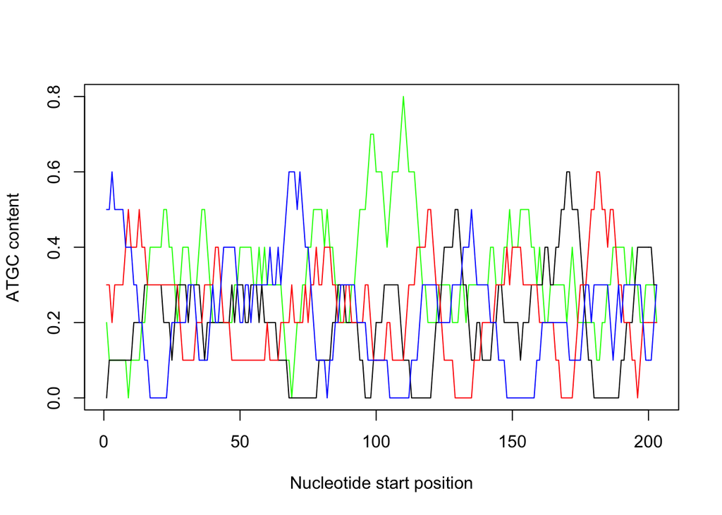

[output not shown]

[output cut: 30 more lines]

```
##   [,171] [,172] [,173] [,174] [,175] [,176] [,177] [,178] [,179] [,180] [,181]
## A    0.3    0.4    0.3    0.2    0.2    0.2    0.2    0.2    0.2    0.2    0.1
## C    0.6    0.5    0.5    0.5    0.4    0.3    0.2    0.1    0.1    0.0    0.0
## G    0.0    0.0    0.1    0.2    0.3    0.3    0.3    0.4    0.5    0.5    0.6
## T    0.1    0.1    0.1    0.1    0.1    0.2    0.3    0.3    0.2    0.3    0.3
##   [,182] [,183] [,184] [,185] [,186] [,187] [,188] [,189] [,190] [,191] [,192]
## A    0.1    0.2    0.2    0.3    0.3    0.4    0.4    0.4    0.4    0.4    0.3
## C    0.0    0.0    0.0    0.0    0.0    0.0    0.0    0.0    0.1    0.1    0.2
## G    0.6    0.5    0.5    0.4    0.5    0.5    0.4    0.3    0.3    0.2    0.2
## T    0.3    0.3    0.3    0.3    0.2    0.1    0.2    0.3    0.2    0.3    0.3
##   [,193] [,194] [,195] [,196] [,197] [,198] [,199] [,200] [,201] [,202] [,203]
## A    0.3    0.4    0.3    0.3    0.2    0.2    0.3    0.3    0.3    0.3    0.2
## C    0.2    0.2    0.3    0.4    0.4    0.4    0.4    0.4    0.4    0.3    0.3
## G    0.2    0.1    0.1    0.0    0.1    0.2    0.2    0.2    0.2    0.2    0.2
## T    0.3    0.3    0.3    0.3    0.3    0.2    0.1    0.1    0.1    0.2    0.3
```

```r
slidinginput<-("AGTTGTTAGTCTGTGTGGACCGACAAGGACAGTTCCAAATCGGAAGCTTGCTTAACACAGTTCTAACAGT
TTGTTTGAATAGAGAGCAGATCTCTGGAAAAATGAACCAACGAAAAAAGGTGGTTAGACCACCTTTCAAT
ATGCTGAAACGCGAGAGAAACCGCGTATCAACCCCTCAAGGGTTGGTGAAGAGATTCTCAACCGGACTTT")
dnaseqtool:::slidingplot(10,slidinginput)
```